# Data Collection for Quantitative Research

GE2021 Research Technology, Fall 2026

Chad (Chungil Chae)

cchae@kean.edu

Tue, 15 September 2026

# Learning Objectives

- 7-1 Familiarize yourself with the details of experimental design.
- 7-2 Familiarize yourself with the details of quasi-experimental design.
- 7-3 Understand the steps of designing a survey study.
- 7-4 Consider additional data collection sources.

## SHORT VIDEO INTRODUCTION

[video not shown]

# Data Collection in Experimental Design

- Experimental designs are unique quantitative studies that include specific details.
- They attempt to investigate the possibility of how variable may affect each other in a controlled setting.

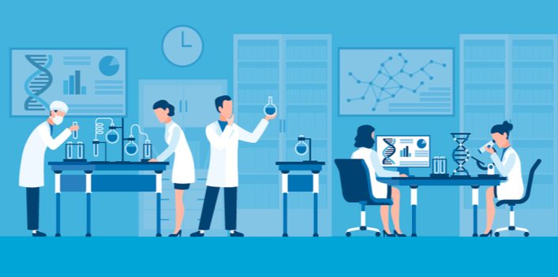

## Review of Experimental Design

- **Quantitative studies** collect information in the form of numbers to standardize information so that it can be processed through statistical tests.
- **Experimental research:** conducting an experiment or intervention on one of the randomly assigned groups in the study while controlling finding with a second group.
  - The experimental group is exposed to a variable of study, while the control group experiences the same conditions, except they do not undergo any manipulation.
  - For an experiment, the researcher needs to:
    - Randomly assign participants into control and experimental groups
    - Conduct a pretest and posttest to measure the expected areas of change
    - Protect findings from other external explanations

## Collecting Data in Experimental Design

- The data collected in the experimental design is the standardized information collected at the beginning and end of the study.
  - In classical experimental design, both the control and intervention groups take pretests and posttests.
  - The pretest is identical to the posttest, and if there is a statistically significant difference between them, the null hypothesis can be rejected.

# Data Collection in Quasi-Experimental Design

- **A classic experimental design** is not always feasible for various reasons
  - Impossibility of randomization, non-equivalent groups available, and so on.
- **Quasi-experimental studies** allow the researcher to conduct some form of intervention, training, or other experiment and measure the impact, without fulfilling all the required conditions for the classic experimental study.

# Data Collection in Surveys

- **Survey:** refers to the method of data collection
- **Questionnaire:** the instrument containing the questions
- **Non-standardized survey questionnaire:** a questionnaire that was never tested for reliability and validity.
- **Standardized survey questionnaire:** a questionnaire that has been tested and is a reliable and valid form of data collection.

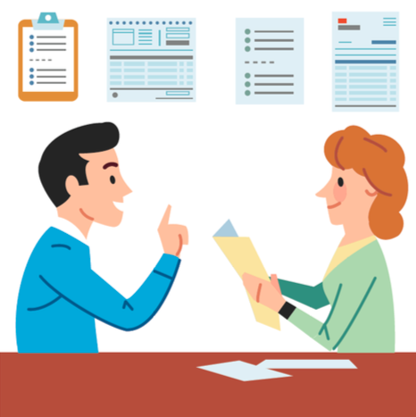

## Steps to Develop Survey

- Step 1. Develop a list of constructs
- Step 2. Determine constructs
- Step 3. Create the first variables
- Step 4. Turn constructs into variables
- Step 5. Tips and ideas on crafting the best possible questions
- Step 6. Organize in a manner that attracts and holds participant attention
- Step 7. Create an answer scale
- Step 8. Conduct a pilot study to evaluate the instrument

## Details in the Steps

- **Step 1. Develop a list of constructs**
  - Developing a complete list of all the items and constructs to be measured in a questionnaire stimulates thinking about ways to measure them.
- **Step 2. Determine constructs**
  - From the list, figure out which ones are constructs and which ones are items to measure.
- **Step 3. Create the first variables**
  - For items to be measured, it is best to look around for established survey instruments that may be related to the study.
  - Some potential sources to find questions are U.S. Census data and questionnaires from organizations such as the Department of Education, Centers for Disease Control and Prevention, and so on.
- **Step 4. Turn constructs into variables**
  - Researchers can consult the literature to look for scientific possibilities and enumerate them on the questionnaire, or create a brief, open-ended question.
  - Closed variables have predefined answers or multiple-choice options that the participant can select from.
    - More specific and can distinguish between categories
  - Open variables are where a participant supplies their own answer in their own words.
    - Not specific and best used to capture opinions, views, and attitudes, especially about sensitive topics.
- **Step 5. Tips and ideas on crafting the best possible questions**
  - **Clarity:** the wording of questions needs to be clear and grammatically correct.
  - **Simplicity:** participants donate their time to fill out a survey, and they should not need to struggle to understand what is being asked in a question.
  - **Unbiased:** avoid guiding participants’ answers.
  - **Intelligible:** use of technical terms can confuse participants.
  - **Avoid Social Desirability:** social desirability is the tendency where participants want to look good and avoid the truth.
- **Avoid double-barreled questions:** double-vision or double-barreled question ask about more than one concept but only allow one answer from the respondent.
- **Avoid double-negatives:** Questions with two negative statements can be unclear.
- **Contingency questions:** contingency questions are follow-up questions at the end of a questionnaire; often a respondent’s answer to a question triggers another question.
- **Avoid dangling alternatives:** dangling alternatives are when alternatives are put in a question before introducing the topic.
- **Avoid hypothetical questions:** they are difficult to capture and may be understood differently by different people.
- **Step 6. Organize in a manner that attracts and holds participant attention**
- When questions bore participants, it can change their attitude towards the entire questionnaire.
- Their attention may decrease as they answer each question, and they are less willing to respond accurately.
- It is best practice to ask demographic questions at the end, after the attention-requiring questions.
  - Participants may also be willing to answer more accurately if they have not yet exposed their identity.
- Questions should also follow a logical sequence.
- Researchers should be wary of using only scale measurements, because participants may start skipping questions or selecting the same rating repetitively.
- **Step 7. Create an answer scale**
  - A scale needs to range from the maximum of a concept to the minimum of the same concept.
  - Depending on the purpose of the question, consider having an odd or even number of response options.
    - If you are looking to force respondents to take a stand, have an even number of options.
  - Answers should be inclusive of all options and gradually progress from one to another.
- **Step 8. Conduct a pilot study to evaluate the instrument**
  - **Pilot study:** a way of testing an instrument with a small group of participants that allows the researcher to get feedback on the instrument from them.
    - It can give the researcher a sense of how much time respondents need to complete it, making recruiting easier.
    - The researcher can determine any issues in understanding questions, their sequence, of it any questions caused discomfort.
    - Participants may volunteer suggestions about certain terms or language that will best convey accurate information.
    - The researcher can test data entry and correct any problems caused during the data collection phase.